# Sensitivity Analyses

Devin Gamble

5/13/2020

## Objective:

#### Determine how sensitivity to different climate variables, for different seasons/months, and for long-term vs anomalouse climate varies

- through time
- Across space (lat, long, elev)
- by climate region

```r
#Load Data

nemo_df2 <- read_csv(here::here("data_cleaning", "nemo_full_1901_2019.csv")) %>%
  mutate(error_bin = as_factor(error_bin)) #Should this be ordered? #Combined specimen & climate data from 1901-2019
#1677 obs, 1251 columns

nemo_df1 <- read_csv(here::here("data_cleaning", "nemo_full_1861_2019.csv")) #Combined data for all years
#1764 obs, 1251 columns


#Set contrasts
options(contrasts = c("contr.sum", "contr.poly"))
```

## Identify Sensitivity to different climatic variables

- See ‘EDA2.Rmd’ for exploration of different models.

*Copied from old Climate_1.RMD –> CLEAN UP*

*CLEAN UPPPPPPP*

*To-Do*  
- Fix & clean up models describing sensitivity to different aspects of local climate  
- Calculate new seasonal windows of climate parameters (and save to csv)  
- Statistically compare slope estimates of climate parameters on DOY to select the most influential parameters  
- Add in PI as a covariate in models

**Formulate New Seasonal Windows?**

ClimateNA wt = Dec - Feb ClimateNA sp = Mar - May

Create *new* averages for seasons:

_wt2 = Nov-Dec; _wt3 = Nov-Jan _sp2 = Feb-Mar; _sp3 = Feb-Apr

## Long-term (100Y) Climate Variables

May also consider:  
- NFFD, bFFP, CMD, RH, DD5, MCMT (see EDA2)

**Annual Variables**

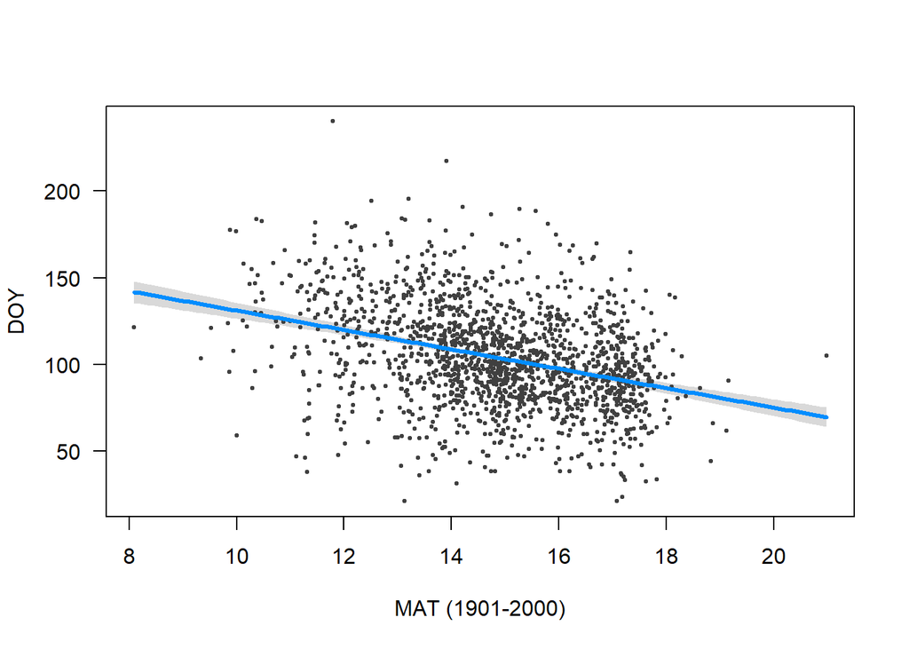

```r
#100Y

ann_clim1 <- lm(DOY ~ MAT_100Y + MAP_100Y, data = nemo_df2)
ann_clim2 <- lm(DOY ~ MAT_100Y + MAP_100Y + elev_m, data = nemo_df2)
ann_clim3 <- lm(DOY ~ MAT_100Y + MAP_100Y + elev_m + long, data = nemo_df2)
ann_clim4 <- lm(DOY ~ MAT_100Y + MAP_100Y + elev_m + long + year, data = nemo_df2) #Best, though adding year doesn't change much
#No interactions

summary(ann_clim1)
summary(ann_clim2)
summary(ann_clim3)
summary(ann_clim4)
#Controlling for elevation severely reduces the effect of MAT (ns)
#Controlling for elev and long - the effect of temperature returns but is still quite small

summ(ann_clim3, vif = TRUE) #VIF for long, elev, MAP, MAT is high

visreg(ann_clim1, "MAT_100Y", xlab = "MAT (1901-2000)", points = list(col = "#404040"))
```

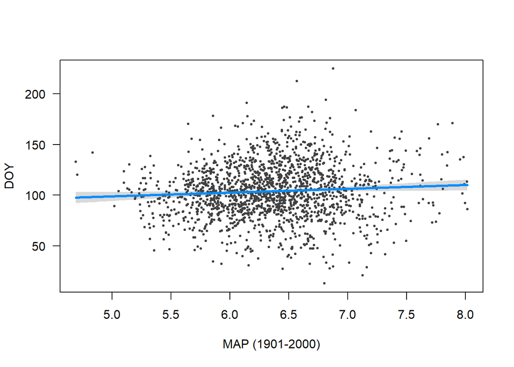

```r
visreg(ann_clim1, "MAP_100Y", xlab = "MAP (1901-2000)", points = list(col = "#404040"))
```

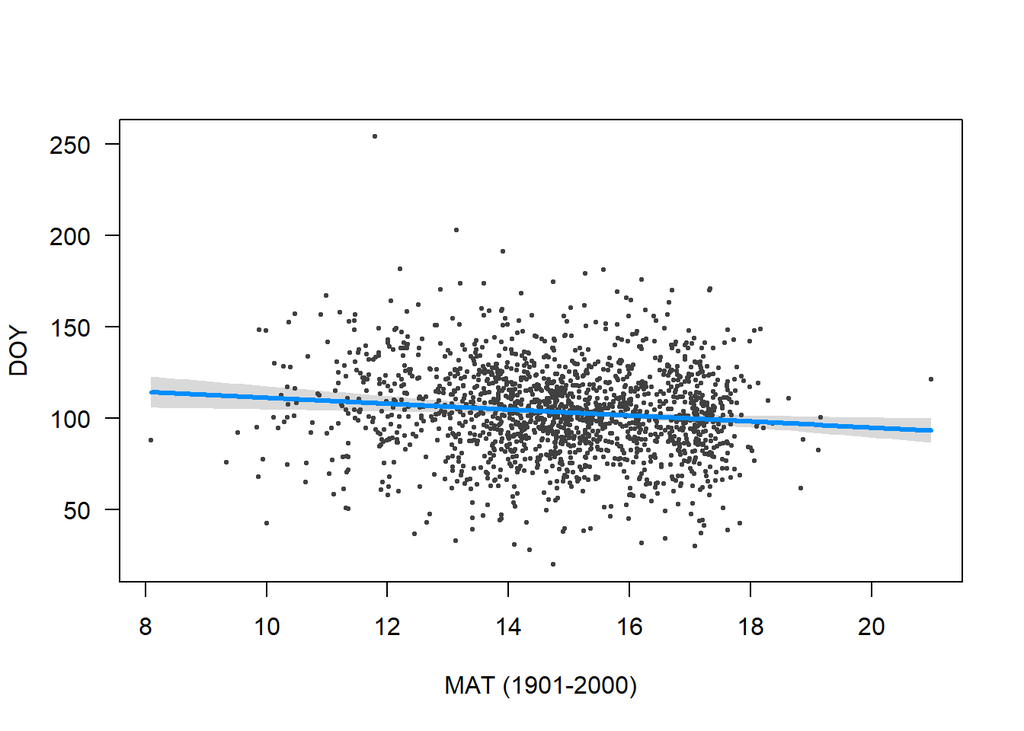

```r
visreg(ann_clim3, "MAT_100Y", xlab = "MAT (1901-2000)", points = list(col = "#404040"))
```

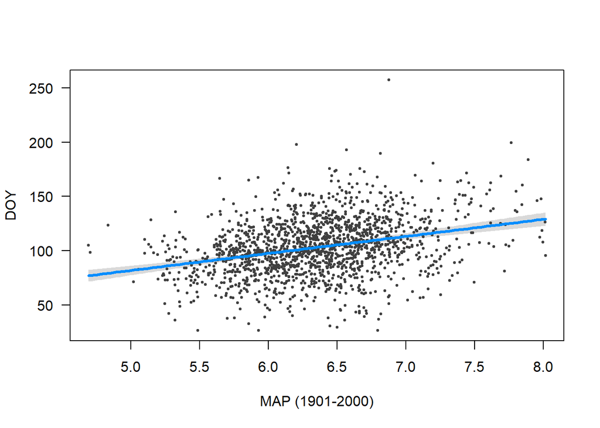

```r
visreg(ann_clim3, "MAP_100Y", xlab = "MAP (1901-2000)", points = list(col = "#404040"))
```

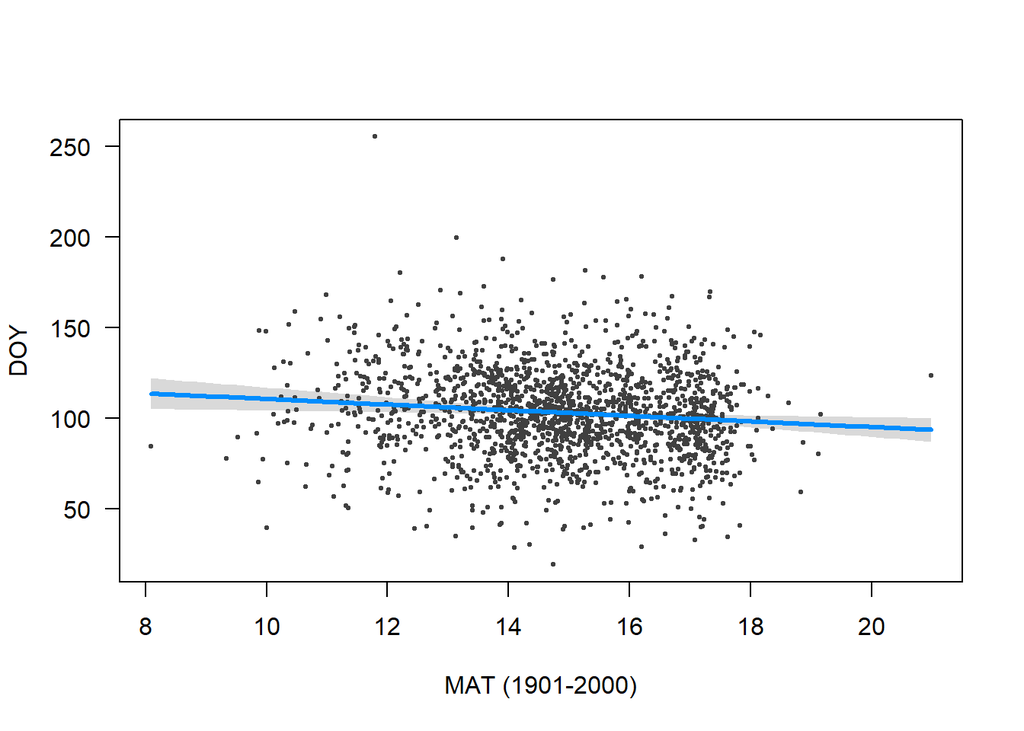

```r
visreg(ann_clim4, "MAT_100Y", xlab = "MAT (1901-2000)", points = list(col = "#404040"))
```

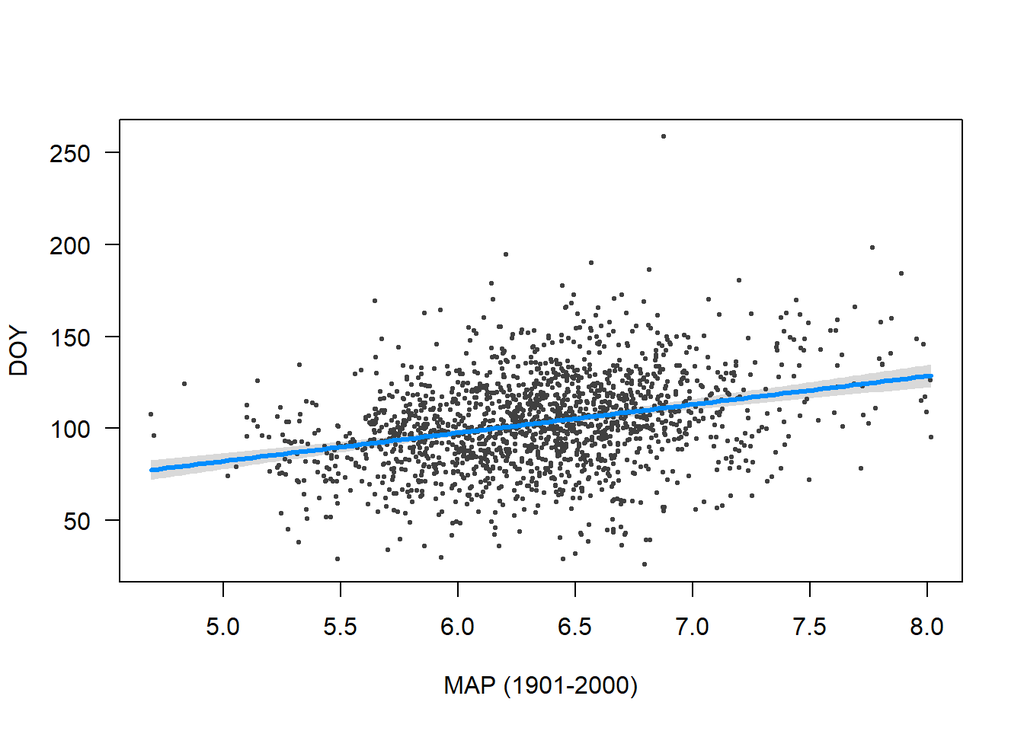

```r
visreg(ann_clim4, "MAP_100Y", xlab = "MAP (1901-2000)", points = list(col = "#404040"))
```

The relationship b/w DOY and MAT weakens as the model is parameterized, while the estimate of MAP strengthens. MAP appears to be driving variation in DOY. There were no significant interactions between any covariates.  
While MAT still appears to advance DOY, controlling for geography seems to explain a good deal of this variation (over a 100-yr avg). Examining seasonal climate and anomalies should shed more light on this.

Note: Everything at the annual scale for 100Y averages is strongly correlated (see EDA2.Rmd). Refer to `ann_clim3` model above (controls for elev_m and long).

**Seasonal Variables**

For Seasonal variables, examine models with: - Tmin & Tave (Winter, spring) [No Tmax]  
- PPT (Winter, Spring, Summer)

May also consider  
- DD > 5 (spring and winter)  
- DD > 18 (spring and summer)  
- CMD (winter, spring, summer)? RH?

From ‘EDA2.Rmd’, Both Spring temperature and precipitation (from 100Y averages) appeared to be the most influential on DOY. Tave had a higher R2 and Beta than Tmin for spring temps…

Winter Conditions

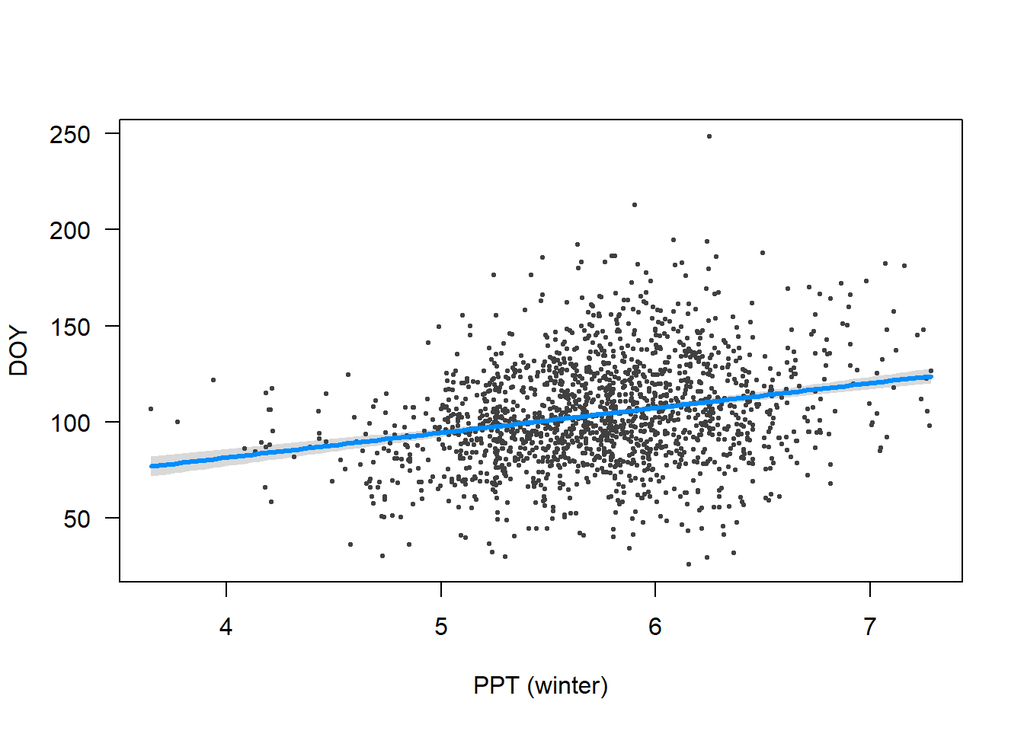

```r
library(interactions)
####Seasonal variables
#Winter Conditions
sz_wt1 <- lm(DOY ~ Tmin_wt_100Y + PPT_wt_100Y, data = nemo_df2)
summary(sz_wt1)

sz_wt1c <- lm(DOY ~ Tmin_wt_100Y + PPT_wt_100Y + elev_m + long + year, data = nemo_df2)
summary(sz_wt1c)

visreg(sz_wt1, xvar = "PPT_wt_100Y", xlab = "PPT (winter)", points = list(col = "#404040"))
```

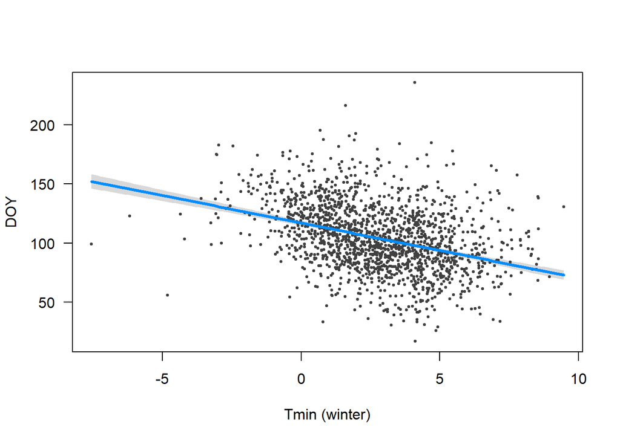

```r
visreg(sz_wt1, xvar = "Tmin_wt_100Y", xlab = "Tmin (winter)", points = list(col = "#404040"))
```

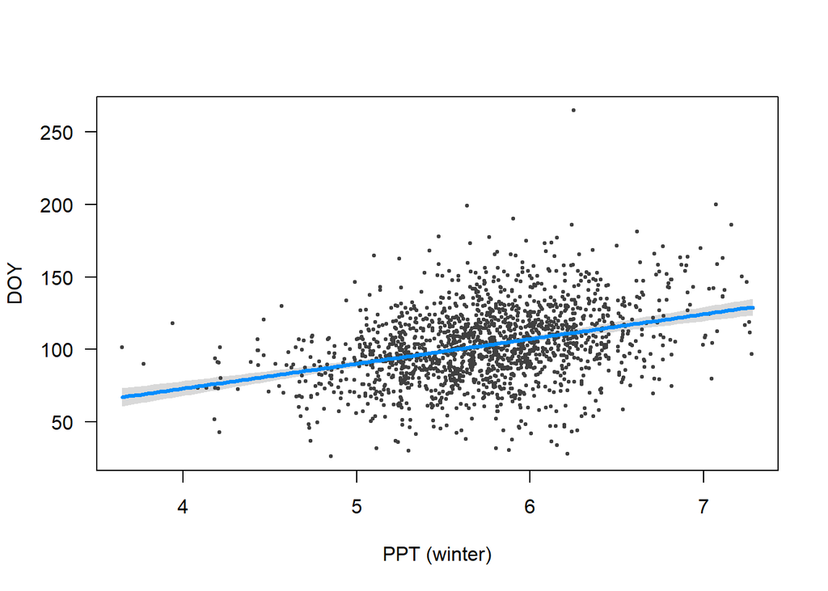

```r
visreg(sz_wt1c, xvar = "PPT_wt_100Y", xlab = "PPT (winter)", points = list(col = "#404040"))
```

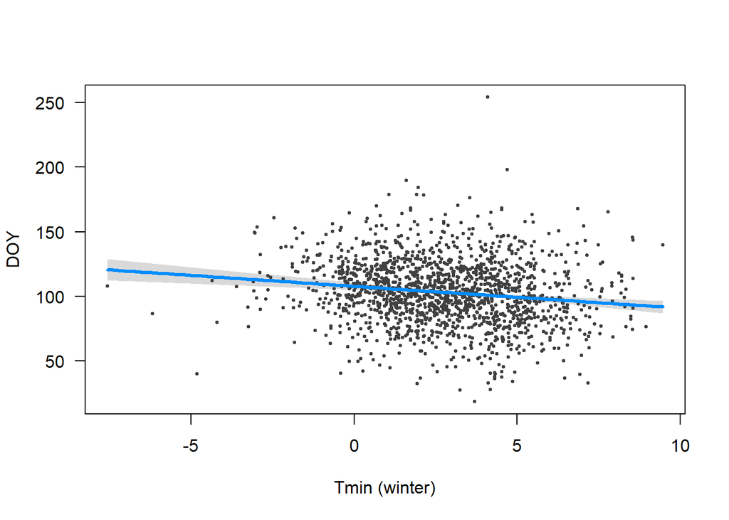

```r
visreg(sz_wt1c, xvar = "Tmin_wt_100Y", xlab = "Tmin (winter)", points = list(col = "#404040"))
```

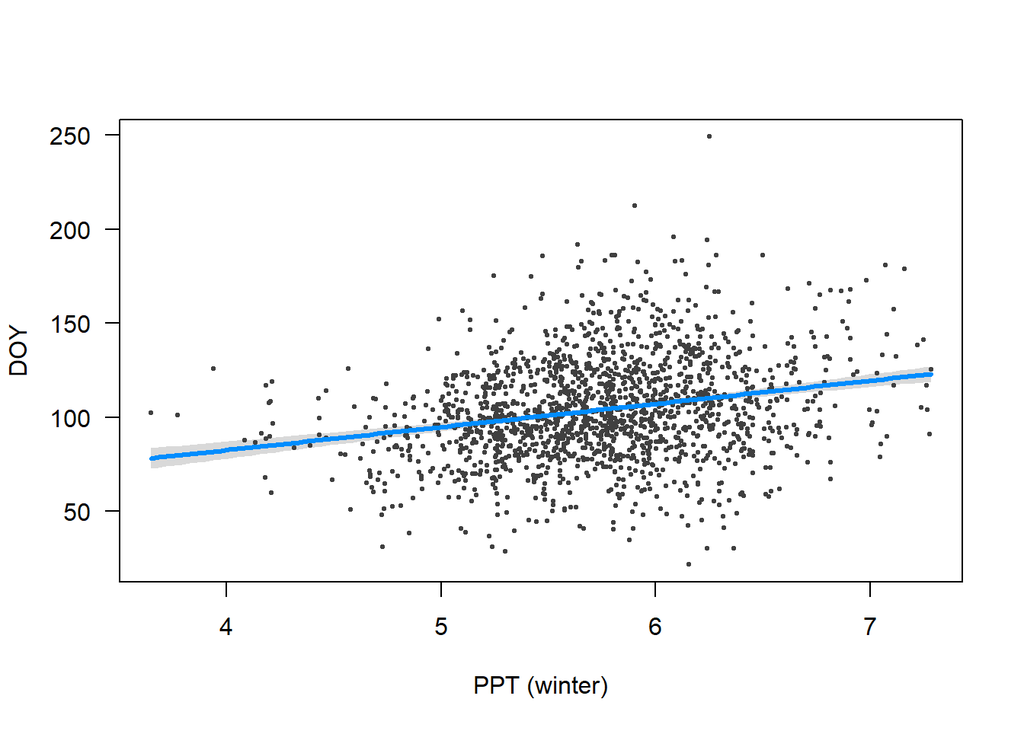

```r
sz_wt1.1 <- lm(DOY ~ Tave_wt_100Y + PPT_wt_100Y, data = nemo_df2)
#summary(sz_clim1.1) #These have low R2 and high SE, plus estimates are crazy


sz_wt1.2 <- lm(DOY ~ PPT_wt_100Y*Tmin_wt_100Y, data = nemo_df2)
summary(sz_wt1.2) #R2 - 0.18, interaction B = -1.25     #Tmin more significant, removed Tave
#Interaction more significant when Tave retained

visreg(sz_wt1.2, xvar = "PPT_wt_100Y", xlab = "PPT (winter)", points = list(col = "#404040"))
```

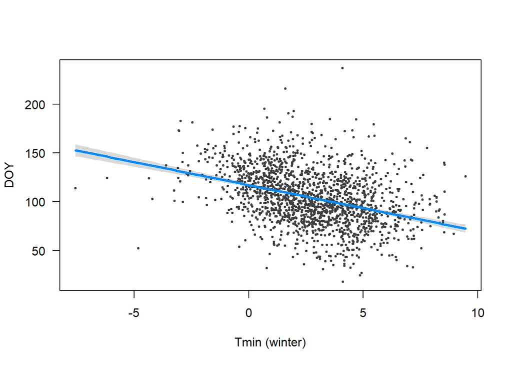

```r
visreg(sz_wt1.2, xvar = "Tmin_wt_100Y", xlab = "Tmin (winter)", points = list(col = "#404040"))
```

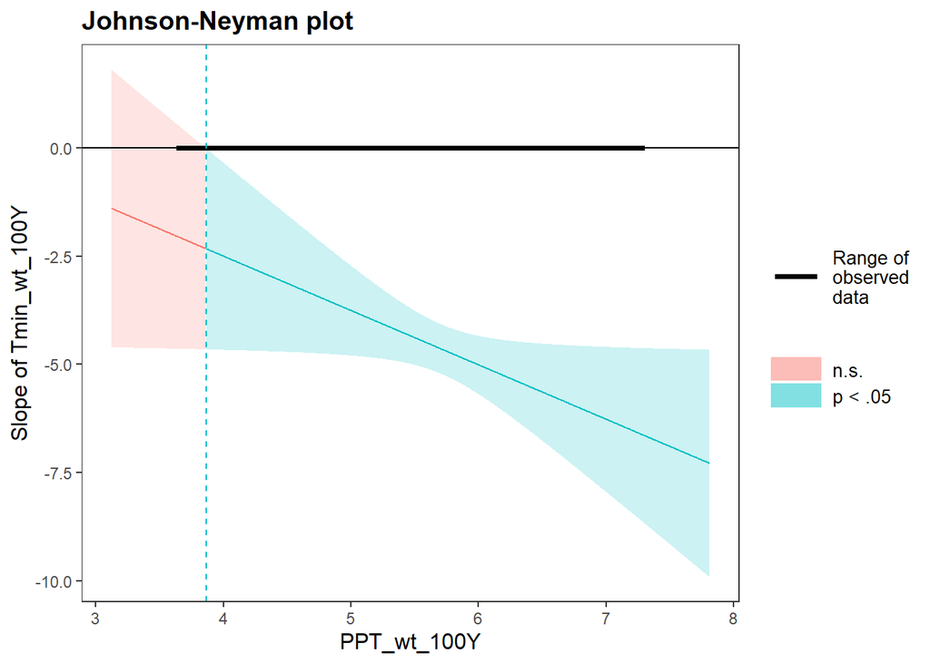

```r
johnson_neyman(sz_wt1.2, pred = "Tmin_wt_100Y", modx = "PPT_wt_100Y")
```

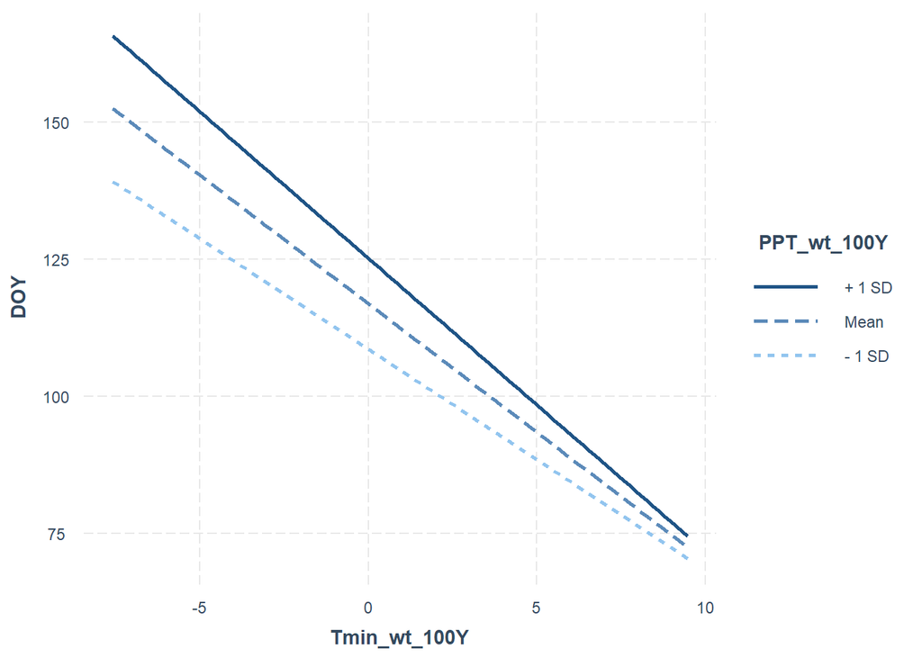

```r
interact_plot(sz_wt1.2, pred = "Tmin_wt_100Y", modx = "PPT_wt_100Y")
```

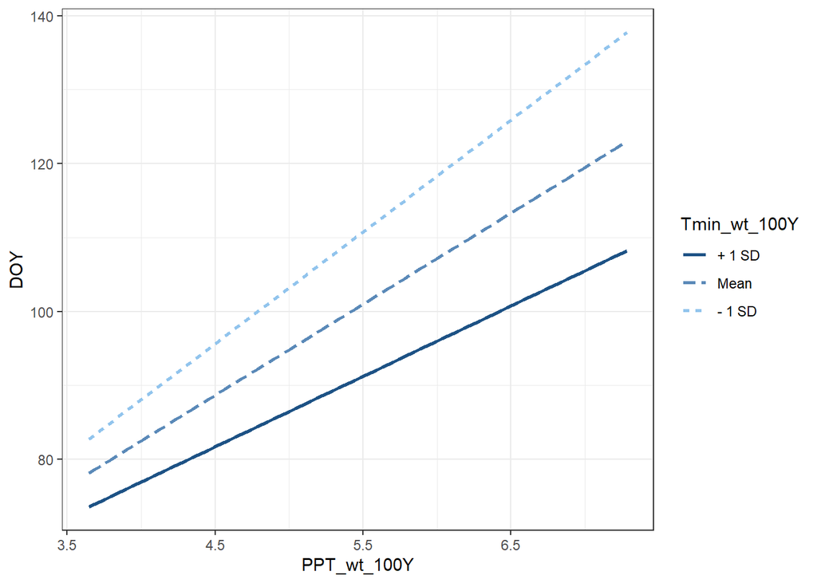

```r
interact_plot(sz_wt1.2, pred = "PPT_wt_100Y", modx = "Tmin_wt_100Y") + theme_bw()
```

Controlling for geographic location (long and elev) [not shown], the interaction between Tmin_wt and PPT_wt disappears. Including year as a covariate slightly improves $R^2$ and Tmin estimate.

Spring Conditions

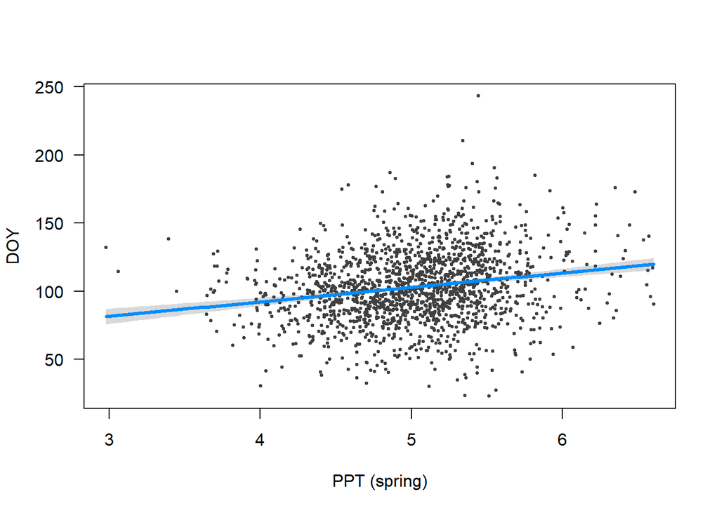

```r
#Spring Conditions
sz_sp1 <- lm(DOY ~ Tmin_sp_100Y + PPT_sp_100Y, data = nemo_df2)
summary(sz_sp1)
sz_sp1.1 <- lm(DOY ~ Tave_sp_100Y + PPT_sp_100Y, data = nemo_df2)
summary(sz_sp1)

sz_sp1c <- lm(DOY ~ Tmin_sp_100Y + PPT_sp_100Y + elev_m + long + year, data = nemo_df2)
summary(sz_sp1c)

visreg(sz_sp1, xvar = "PPT_sp_100Y", xlab = "PPT (spring)", points = list(col = "#404040"))
```

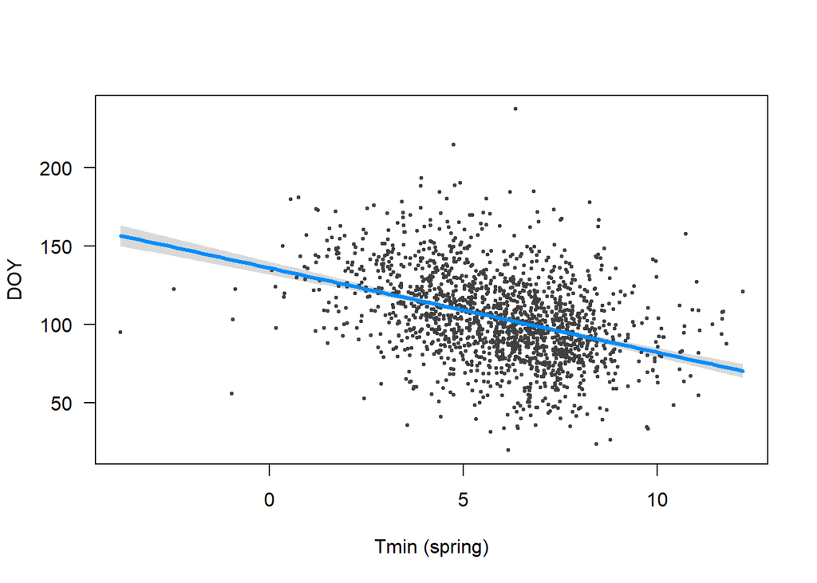

```r
visreg(sz_sp1, xvar = "Tmin_sp_100Y", xlab = "Tmin (spring)", points = list(col = "#404040"))
```

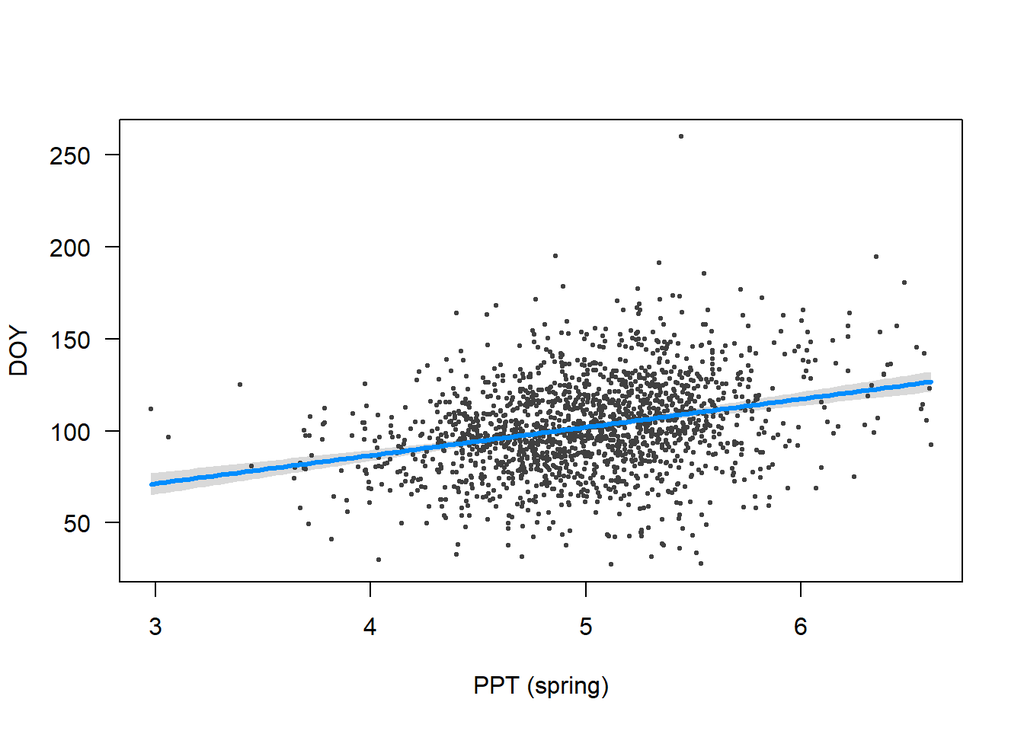

```r
visreg(sz_sp1c, xvar = "PPT_sp_100Y", xlab = "PPT (spring)", points = list(col = "#404040"))
```

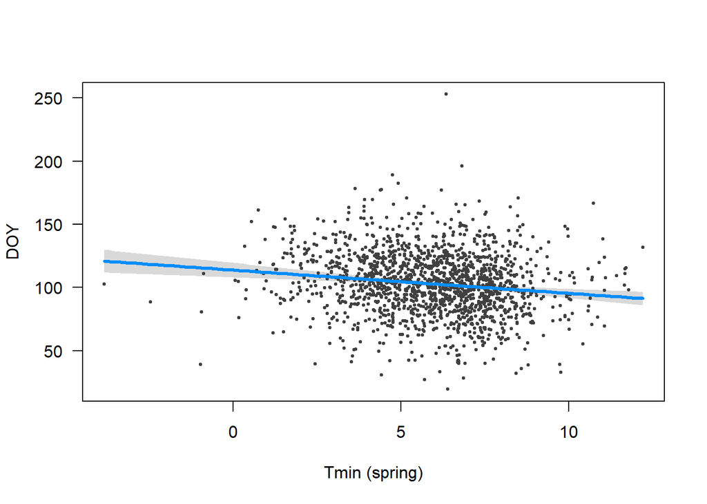

```r
visreg(sz_sp1c, xvar = "Tmin_sp_100Y", xlab = "Tmin (spring)", points = list(col = "#404040"))
```

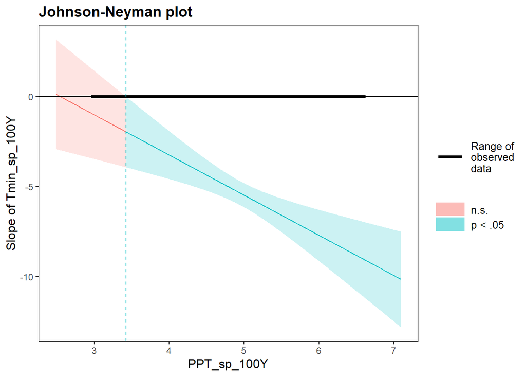

```r
#Interactions
sz_sp1.2 <- lm(DOY ~ Tmin_sp_100Y*PPT_sp_100Y, data = nemo_df2)
summary(sz_sp1.2) #Interaction with Tmin much more significant, higher R2 and estimate
#Tave does still explain some variation, despite the interaction. Removed


johnson_neyman(sz_sp1.2, pred = "Tmin_sp_100Y", modx = "PPT_sp_100Y")
```

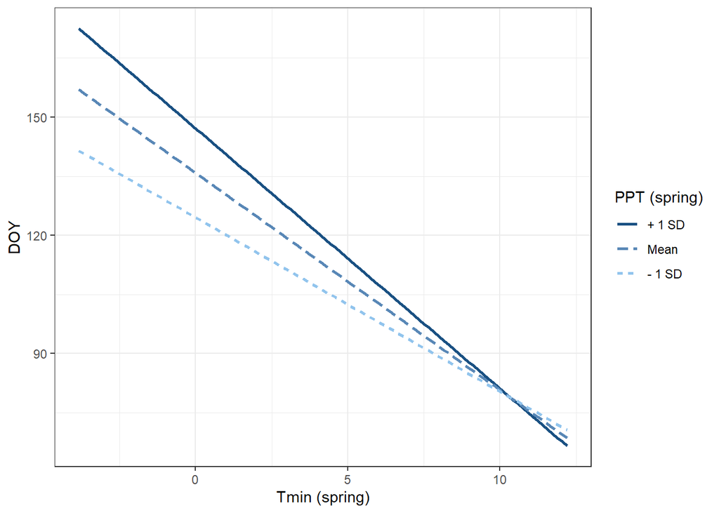

```r
interact_plot(sz_sp1.2, pred = "Tmin_sp_100Y", modx = "PPT_sp_100Y", x.label = "Tmin (spring)", legend.main = "PPT (spring)") + theme_bw()
```

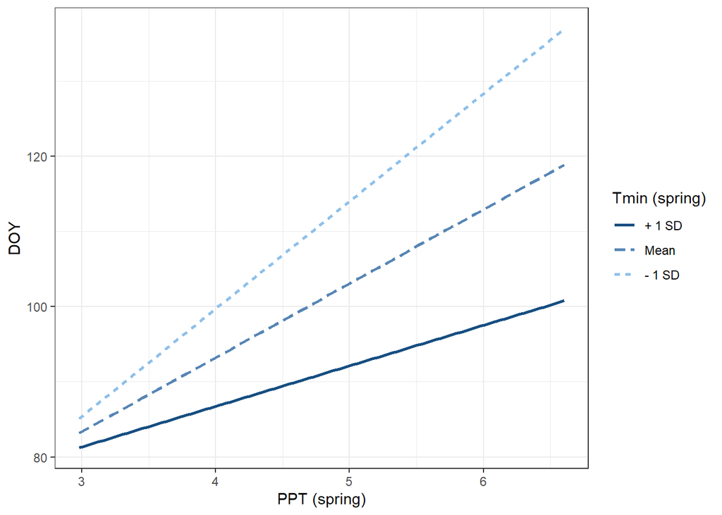

```r
interact_plot(sz_sp1.2, pred = "PPT_sp_100Y", modx = "Tmin_sp_100Y", x.label = "PPT (spring)", legend.main = "Tmin (spring)") + theme_bw()
```

```r
#Swapping Tave for DD>5: similar but much weaker. DD v correlated to Tave
```

Interaction term becomes marginally significant. Removing it, we see results similar to the above winter ‘standard’ model - advancing effect of Tmin (+ year), delaying effect of PPT (+ long, elevation)

Tmin appears to explain more variation than Tave *in its interaction with PPT_sp*. Interaction is stronger with Tmin than Tave and PPT. Better $R^2$ and AIC with Tmin model (no interaction).

[Summer conditions are likely not biologically important in the phenology of N menziesii, patterns due to correlation]

Winter x Spring

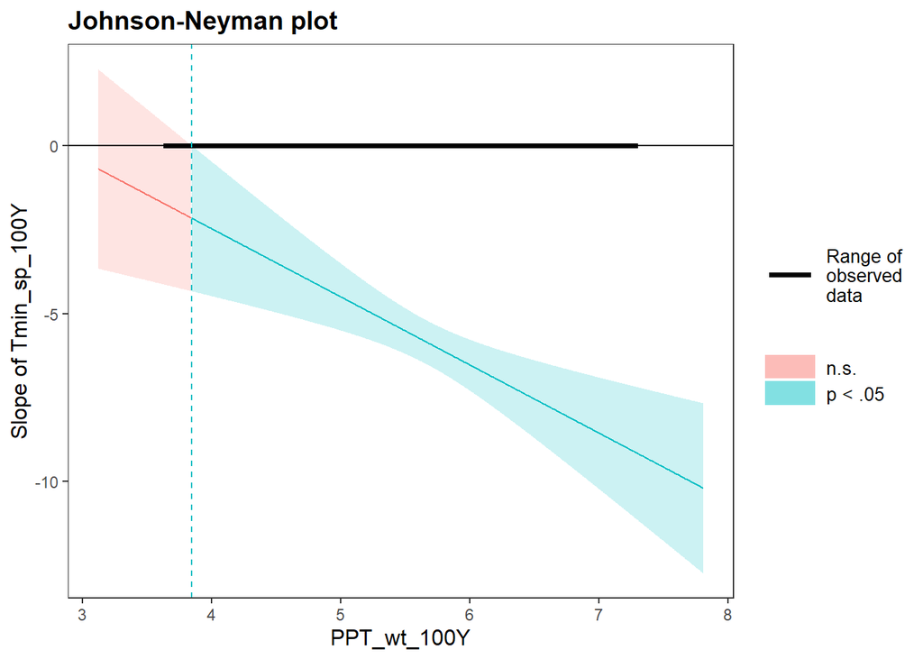

```r
sz_wt_sp1 <- lm(DOY ~ Tmin_sp_100Y + PPT_wt_100Y, data = nemo_df2)
summary(sz_wt_sp1)

sz_wt_sp1.1 <- lm(DOY ~ Tmin_sp_100Y + PPT_wt_100Y + Tmin_sp_100Y*PPT_wt_100Y, data = nemo_df2)
summary(sz_wt_sp1.1)

johnson_neyman(sz_wt_sp1.1, pred = "Tmin_sp_100Y", modx = "PPT_wt_100Y")
```

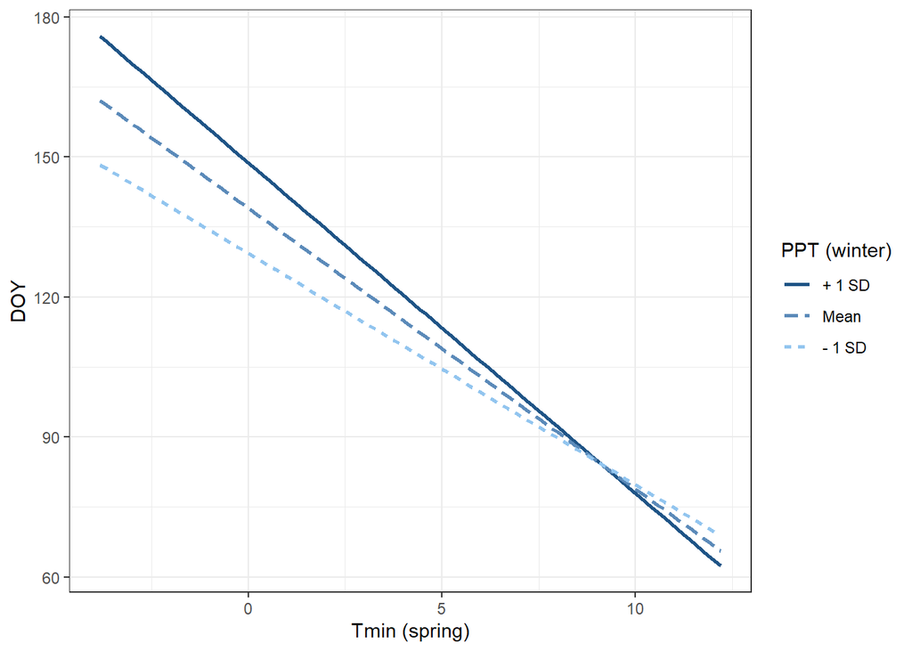

```r
interact_plot(sz_wt_sp1.1, pred = "Tmin_sp_100Y", modx = "PPT_wt_100Y", x.label = "Tmin (spring)", legend.main = "PPT (winter)") + theme_bw()
```

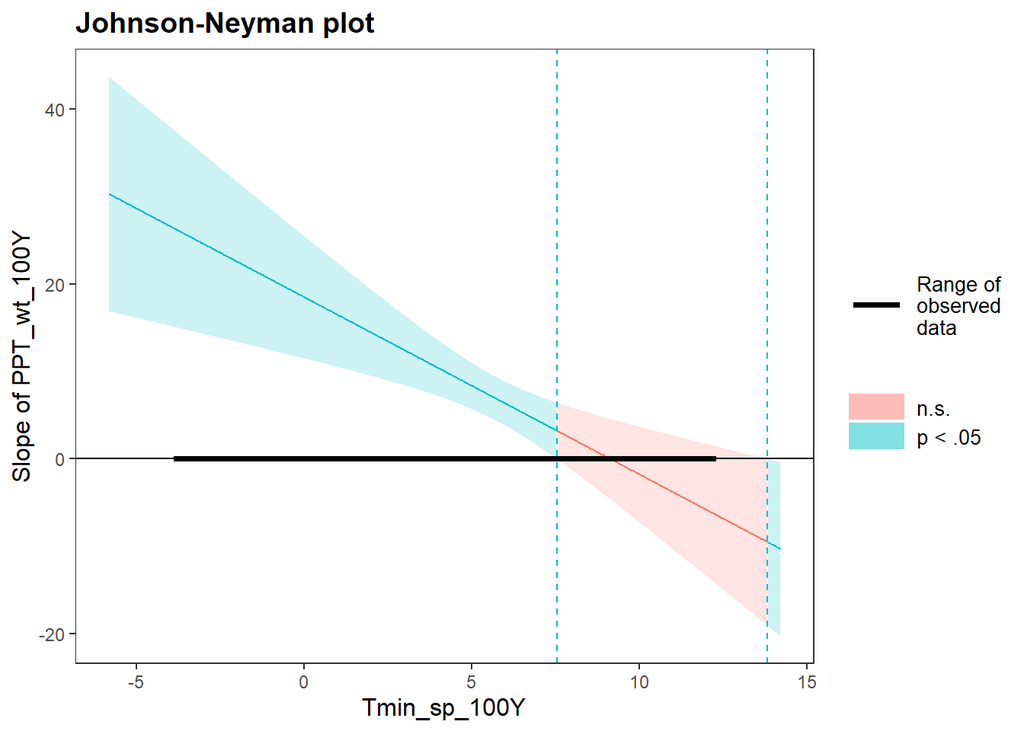

```r
johnson_neyman(sz_wt_sp1.1, pred = "PPT_wt_100Y", modx = "Tmin_sp_100Y")
```

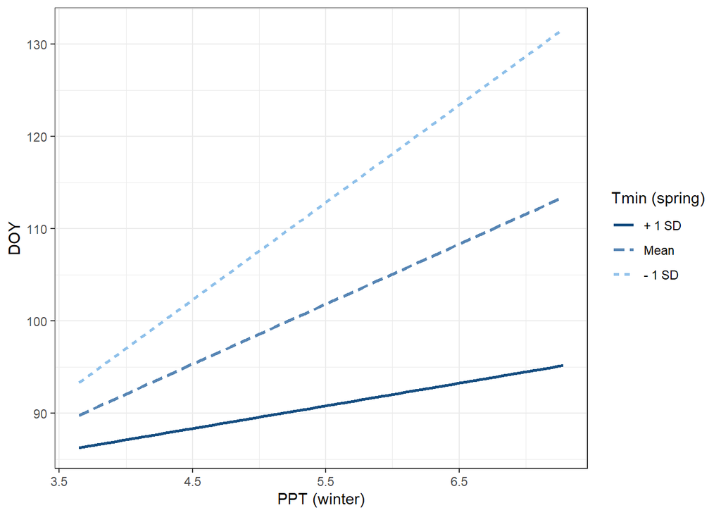

```r
interact_plot(sz_wt_sp1.1, pred = "PPT_wt_100Y", modx = "Tmin_sp_100Y", x.label = "PPT (winter)", legend.main = "Tmin (spring)") + theme_bw()
```

Comparing Models *Error on 262, fix and remove eval = FALSE*

Year of Collection Models [or Anomaly Models]